# LinTInd - tutorial

Luyue Wang

2021/12/22

## Introduction

Single-cell RNA sequencing has become a common approach to trace developmental processes of cells, however, using exogenous barcodes is more direct than predicting from expression profiles recently, based on that, as gene-editing technology matures, combining this technological method with exogenous barcodes can generate more complex dynamic information for single-cell. In this application note, we introduce an R package: LinTInd for reconstructing a tree from alleles generated by the genome-editing tool known as CRISPR for a moderate time period based on the order in which editing occurs, and for sc-RNA seq, ScarLin can also quantify the similarity between each cluster in three ways.

## Installation

Via GitHub

```
devtools::install_github("mana-W/LinTInd")
```

Via Bioconductor

```
if (!requireNamespace("BiocManager", quietly = TRUE))
    install.packages("BiocManager")

BiocManager::install("LinTInd")
```

```r
library(LinTInd)
```

## Import data

The input for LinTInd consists three required files:

- sequence
- reference
- position of cutsites

and an optional file:

- celltype

```r
data<-paste0(system.file("extdata",package = 'LinTInd'),"/CB_UMI")
fafile<-paste0(system.file("extdata",package = 'LinTInd'),"/V3.fasta")
cutsite<-paste0(system.file("extdata",package = 'LinTInd'),"/V3.cutSites")
celltype<-paste0(system.file("extdata",package = 'LinTInd'),"/celltype.tsv")
data<-read.table(data,sep="\t",header=T)
ref<-ReadFasta(fafile)
cutsite<-read.table(cutsite,col.names = c("indx","start","end"))
celltype<-read.table(celltype,header=T,stringsAsFactors=F)
```

For the sequence file, only the column contain reads' strings is requeired, the cell barcodes and UMIs are both optional.

```r
head(data,3)
```

```
##                                   Read.ID
## 1  @A01045:289:HM7K3DRXX:2:2101:9896:1031
## 2 @A01045:289:HM7K3DRXX:2:2101:13367:1031
## 3  @A01045:289:HM7K3DRXX:2:2101:9959:1047
##                                                                                                                                                                                                                                                     Read.Seq
## 1 GAACGCGTAGGATAACATGGCCATCATCAAGGAGTTCTCATGCGCTTCAAGGTGCACATG…
## 2 GAACGCGTAGGATAACATGGCCATCATCAAGGAGTTCTCATGCGCTTCAAGGTGCACATG…
## 3 GAACGCGTAGGATAACATGGCCATCATCAAGGAGTTCTCATGCGCTTCAAGGTGCACATG…
##            Cell.BC        UMI
## 1 GAAGGGTAGCCTCAGC CTTCTCCCGA
## 2 ACCCTCACAAGACTGG TGTAATTTTT
## 3 GAAGGGTAGCCTCAGC CTTCTCCCGA
```

```r
ref
```

```
## $scarfull
## 333-letter DNAString object
## seq: GAACGCGTAGGATAACATGGCCATCATCAAGGAGTT...GGAAGTTGCCACTCCAGTGCCCACCAGCCTTGTCCT
```

```r
cutsite
```

```
##   indx start end
## 1    0    39 267
## 2    1     1  23
## 3    2    28  50
## 4    3    55  77
## 5    4    82 104
## 6    5   109 131
## 7    6   136 158
## 8    7   163 185
```

```r
head(celltype,3)
```

```
##            Cell.BC Cell.type
## 1 AAGCGAGTCTTCTGTA         A
## 2 AATCGACTCGTAGTGT         A
## 3 ACATGCAGTCCACACG         A
```

## Array identify and indel visualization

In the first step, we shold use `FindIndel()` to alignment and find indels, and the function `IndelForm()` will help us to generate an array-form string for each read.

```r
scarinfo<-FindIndel(data=data,scarfull=ref,scar=cutsite,indel.coverage="All",type="test",cln=8)
scarinfo<-IndelForm(scarinfo,cln=4)
```

Then for single-cell sequencing, we shold define a final-version of array-form string for each cell use `IndelIdents()`, there are three method are provided :

- *"reads.num"*(default): find an array-form stirng supported by most reads in a cell
- *"umi.num"*: find an array-form stirng supported by most UMIs in a cell
- *"consensus"*: find the consistent sequences in each cell, and then generate array-form strings from the new reads

For bulk sequencing, in this step, we will generate a "cell barcode" for each read.

```r
cellsinfo<-IndelIdents(scarinfo,method.use="umi.num",cln=4)
```

After define the indels for each cell, we can use `IndelPlot()` to visualise them.

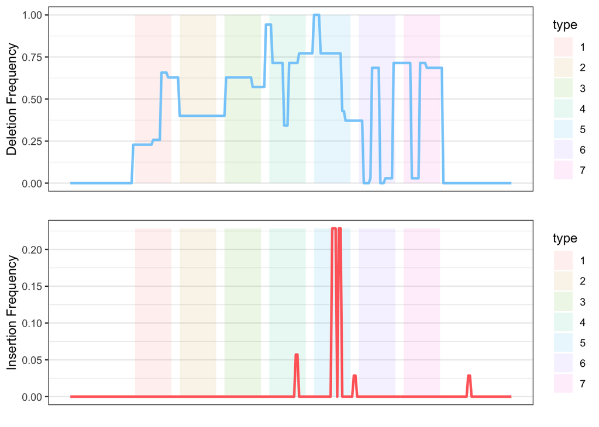

```r
IndelPlot(cellsinfo = cellsinfo)
```

## Indel extract and similarity calculate

We can use the function `TagProcess()` to extract indels for cells/reads. The parameter *Cells* is optional.

```r
tag<-TagProcess(cellsinfo$info,Cells=celltype)
```

And if the annotation of each cells are provided, we can also use `TagDist()` to calculate the relationship between each group in three way:

- *"Jaccard"*(default): calculate the weighted jaccard similarity of indels between each pair of groups
- *"P"*: right-tailed test, compare the Indels intersection level with the hypothetical result generated from random editing, and the former is expected to be significantly higher than the latter
- *"spearman"*: Spearman correlation of indels between each pair of groups

The heatmap of this result will be saved as a pdf file.

```r
tag_dist=TagDist(tag,method = "Jaccard")
tag_dist
```

```
##           A         B         C         D         E
## A 1.0000000 0.4925373 0.2794118 0.2985075 0.2058824
## B 0.4925373 1.0000000 0.5588235 0.6060606 0.4117647
## C 0.2794118 0.5588235 1.0000000 0.9047619 0.7500000
## D 0.2985075 0.6060606 0.9047619 1.0000000 0.6666667
## E 0.2058824 0.4117647 0.7500000 0.6666667 1.0000000
```

## Tree reconstruct

In the laste part, we can use `BuildTree()` to Generate an array generant tree.

```r
treeinfo<-BuildTree(tag)
```

Finally, we can use the function `PlotTree()` to visualise the tree created before.

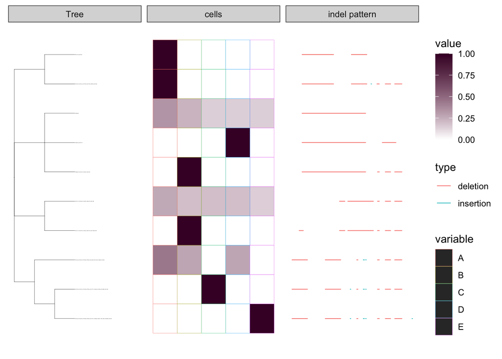

```r
plotinfo<-PlotTree(treeinfo = treeinfo,data.extract = "T",annotation = "T")
plotinfo$p
```